# BM432 Data Visualisation Workshop

## Critique 1.2

**Issue**

Incomplete presentation of statistical comparisons, e.g is there a difference between A16 and A18 in (B)?

**Solution**

Present a table of statistical differences instead, or alongside the figure.

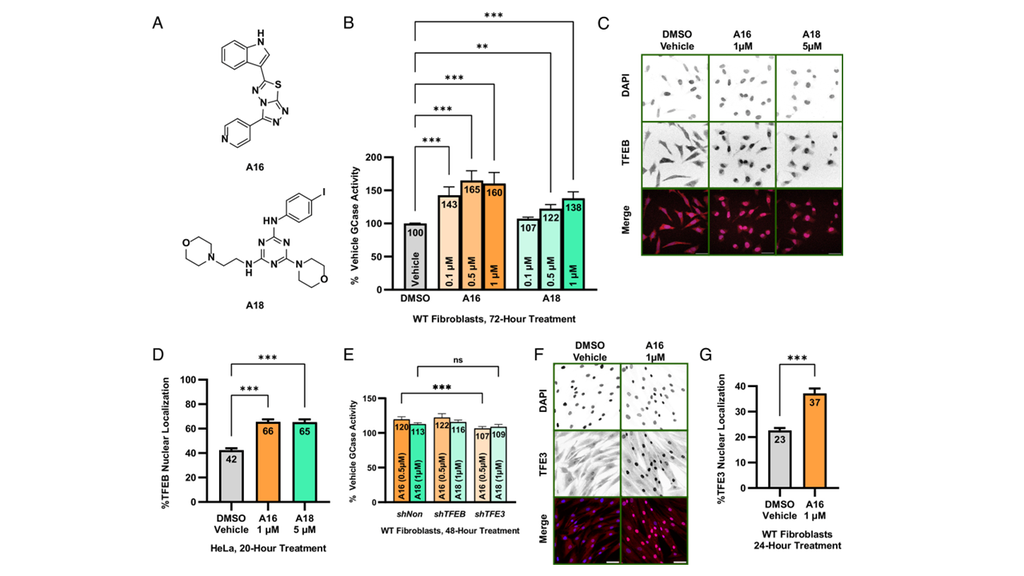

## Critique 1.3

**Issue**

Distance between bars makes comparison awkward.

**Solution**

Place things to be compared by the reader next to each other where possible, to facilitate visual comparison.

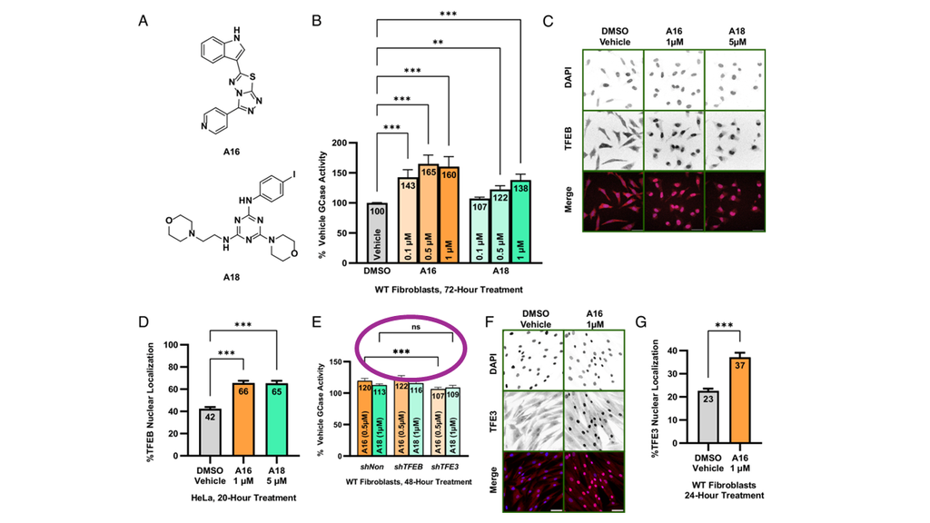

## Critique 1.4

**Issue**

The scale on the micrographs (especially in panel C) is too small to read easily.

**Solution**

Increase the size of the scale relative to the figure so it can be read.

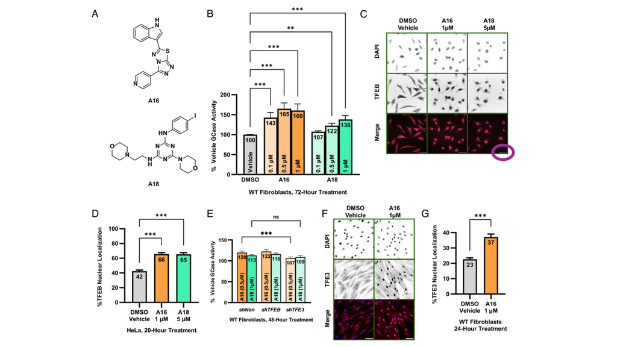

## Critique 1.5

**Issue**

A visual control (bright-field image) is absent.

**Solution**

In addition to showing DAPI and immunofluorescence images of the cells, include a bright-field micrograph of the cells (no fluorescence).

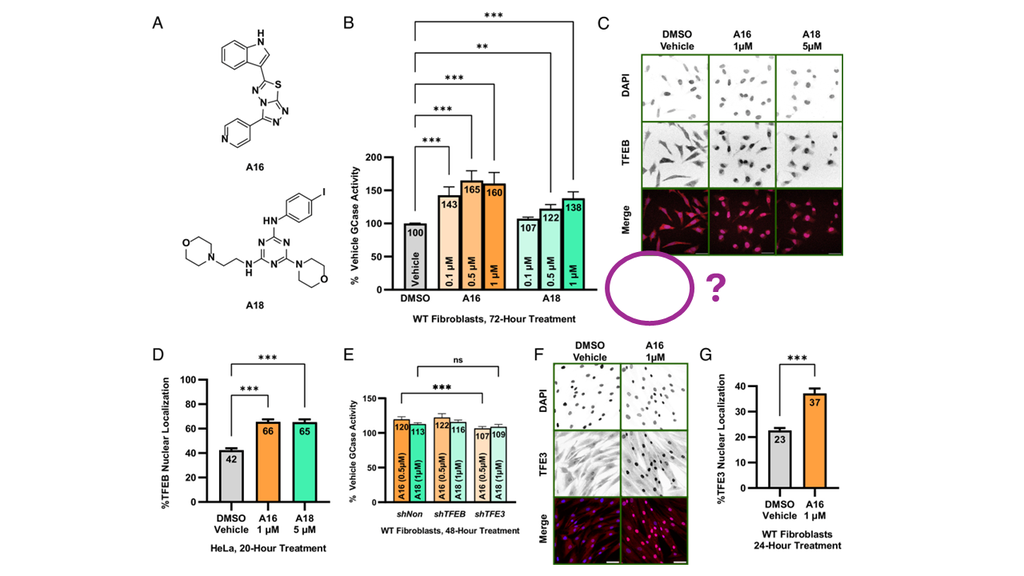

## Critique 1.6

**Issue**

The colour scheme is misleading because saturation represents different data across figure panels (compare 1 $\mu$M A18 in B vs 5 $\mu$M in D, and 1 $\mu$M A18 in E).

**Solution**

Be consistent with the visual messaging of colour (hue, saturation, and luminance).

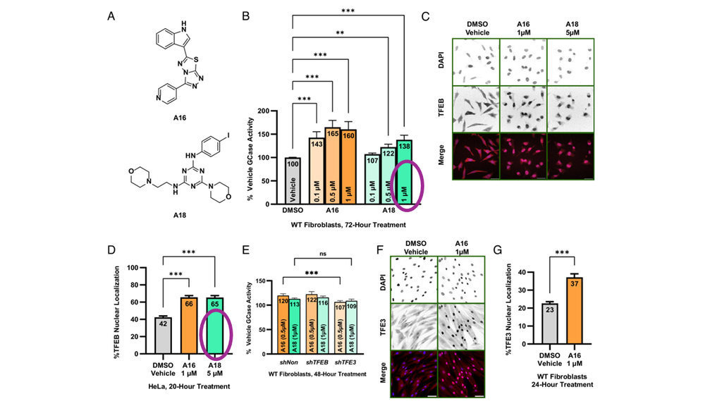

## Critique 1.7

**Issue**

Too many comparisons in B clutter the figure and compress the space available for showing data.

**Solution**

Present a table of statistical differences instead, or alongside the figure, to reduce clutter.

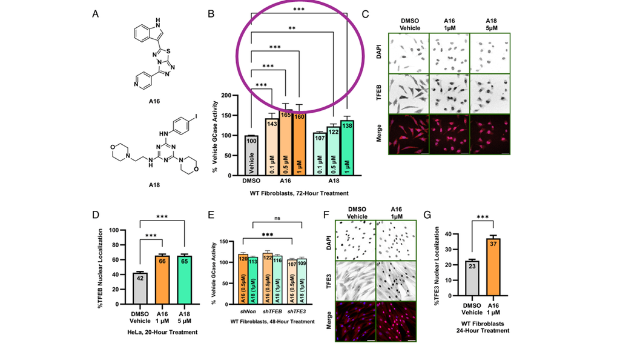

## Critique 1.8

**Issue**

$y$-axis scales vary between panels, so quantitative comparison between panels is difficult.

**Solution**

Use the same $y$-axis scale in all panels to facilitate direct comparison.

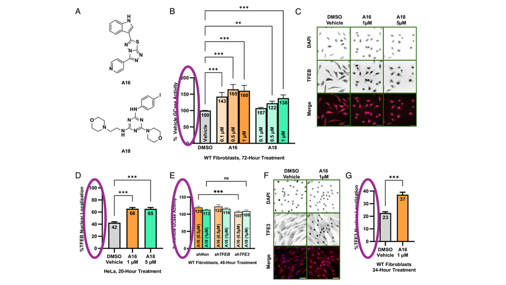

## Our Critical Analysis

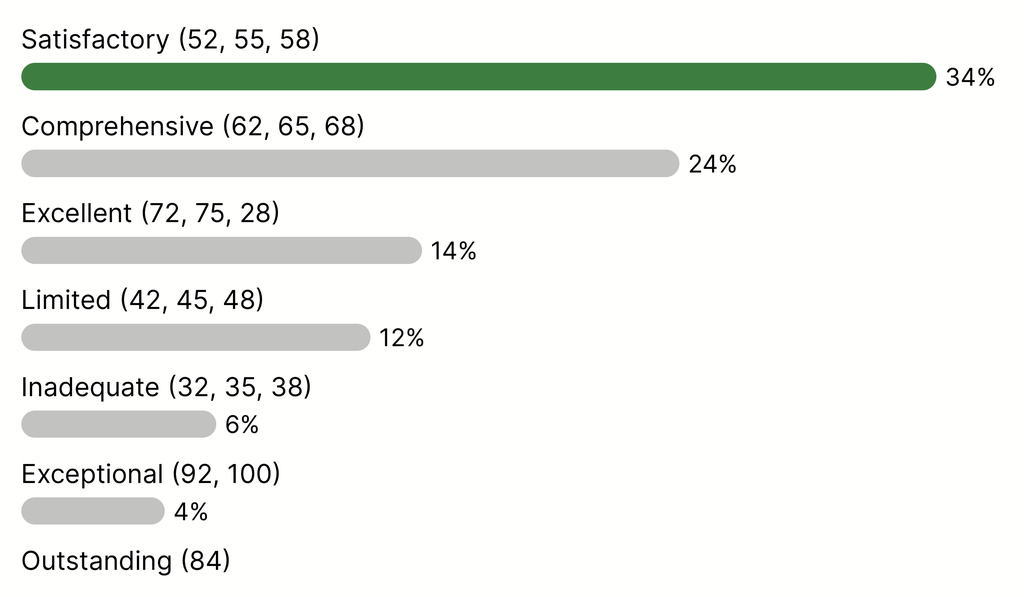

Post-survey results

## Example 2

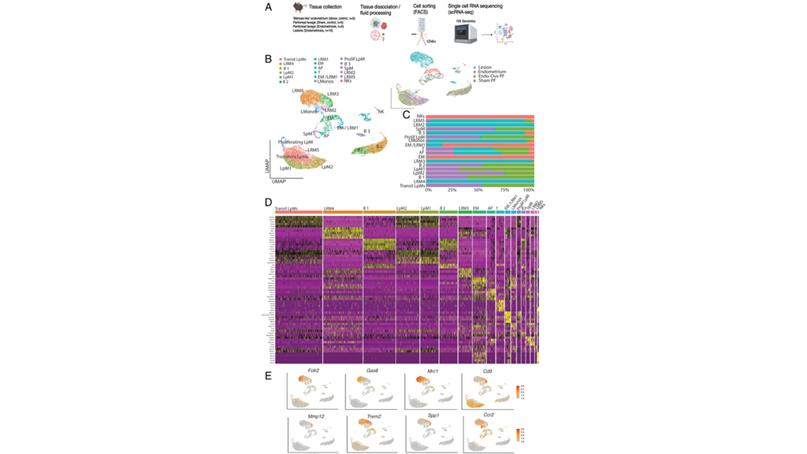

Figure 2: Endometriosis-associated macrophages exhibit significant transcriptomic heterogeneity.